[figure not shown]

**Sábado 16 de mayo, 2020**

## Segundo informe de avance para participantes

En MOVID-19 llevamos más de cuatro semanas recolectando información semanal sobre el estado de salud de chilenos y chilenas en el contexto de la crisis sanitaria por COVID-19. Gracias a los aportes de nuestros participantes, podemos hoy empezar a describir el desarrollo de esta crisis en el tiempo. En este informe, reportamos el resultado de 79.818 observaciones correspondientes a 26.303 personas que, a lo largo de nuestro país, han participado al menos dos veces registrando su situación de salud.

### Qué hemos aprendido

Entre los participantes MOVID-19 hemos observado un mayor número de salidas de casa durante las últimas semanas (ver Figura 1). Este aumento es particularmente notorio en el caso de las personas que han debido salir a trabajar al menos una vez la última semana. Si bien pocas personas reciben visitas en casa, también aquí parece existir un ligero incremento. Como es de esperar, las salidas son menores cuando las personas viven en comunas que se encuentran con cuarentena obligatoria. Para lograr contener la enfermedad, debemos continuar los esfuerzos por quedarnos en casa lo más posible, en particular evitando salir a realizar actividades que no sean absolutamente necesarias.

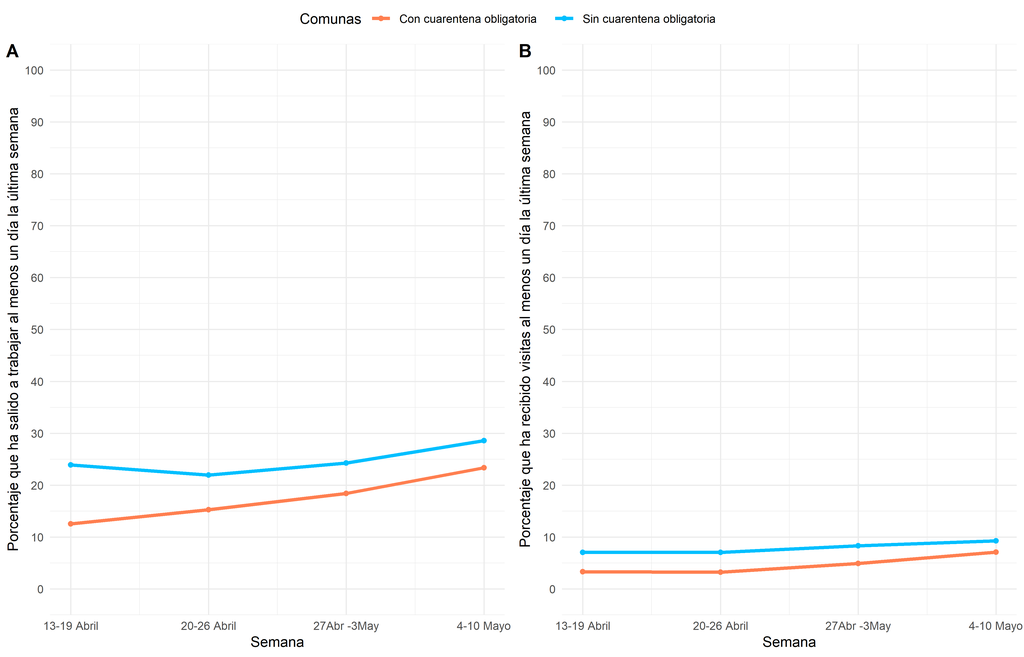

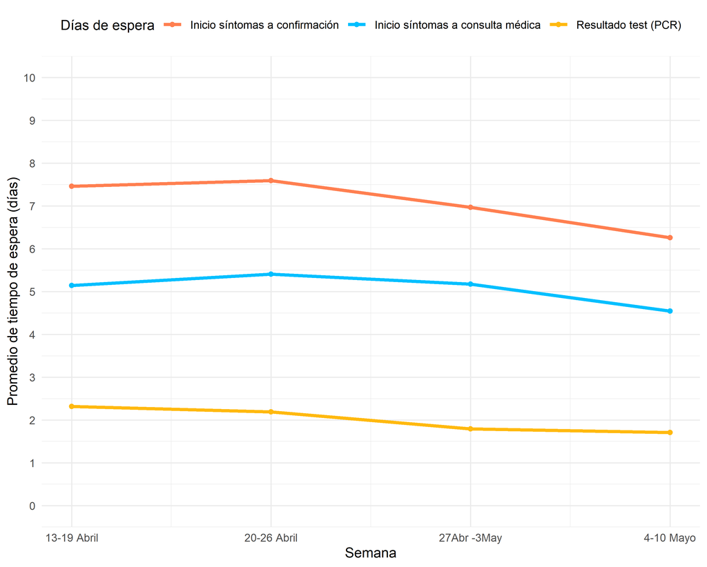

Figura 2. Tiempos de espera (en días) desde el inicio de los síntomas hasta la consulta médica y la confirmación del examen, así como para la obtención de los resultados del test (PCR). (MOVID-19, n observaciones = 79.818)

### Cómo seguir aportando

MOVID-19 está comenzando a proveer información relevante para entender y controlar la crisis sanitaria que hoy está viviendo nuestro país. Para continuar este gran esfuerzo, necesitamos de su colaboración:

- Siga completando de manera semanal su situación actual de salud. Esta información es importante, sin importar si su situación ha cambiado o si se mantiene igual. Cuando sea el momento de contestar, le enviaremos un correo electrónico con una invitación dedicada para Ud.
- Invite a más personas a participar. Comparta el vínculo http://contesta.movid19.cl en su comunidad, lugar de trabajo o estudio, a sus amigos o familia. Necesitamos llegar a la mayor cantidad de personas mayores de 18 años que viven en Chile.
- ¡Siga manteniendo distancia física y quédandose en casa lo más posible!

### ¡Esta pandemia la enfrentamos entre todas y todos!

Gracias por seguir participando en MOVID-19,

**Equipo MOVID-19**  
**Colegio Médico de Chile**  
**Universidad de Chile**

**Institución asociada: Facultad de Psicología, Universidad Diego Portales**

**Contacto: encuestacovid@uchile.cl**